# Two levels of engagement: enrolments, the students who mix them, and the order they came in

multilpa

2026-09-20

## Where this sits

The README fits `multilpa()` to show the syntax. `vignette("multilpa")` walks the argument for the second level from a standing start. Neither is the thing an analyst actually arrives wanting: one model, taken end to end, with every claim followed by the check that would have caught it if it were wrong.

This tutorial is that pass. It is deliberately a *verification* document. Each section states what the model says and then asks what would have to be true for that statement to be an artefact — of the optimiser, of a class count nobody chose in the open, of an assumption the model makes silently, of a covariate entered at the wrong step, or of a posterior too blurred to act on.

One of those checks convicts. Section 2 will find a class count it cannot justify on the usual grounds, section 7 will find out why, and the two sections together are the argument this document most wants to make: **a model can converge from every start, win almost every information criterion, and still be the wrong model.**

Every number below is computed by this document when it renders, from data that ship with the package. Nothing here depends on a file you do not have.

```r
library(multilpa)
```

One dataset carries the whole tutorial.

```r
str(course_engagement)
```

```
#> 'data.frame':    1422 obs. of  11 variables:
#>  $ student       : int  1 1 1 1 1 1 1 1 1 1 ...
#>  $ course        : int  23 19 4 18 16 29 30 31 6 12 ...
#>  $ sequence      : int  1 2 3 4 5 6 7 8 9 10 ...
#>  $ browse        : num  4.23 4.08 2.14 3.89 2.72 3.05 3.85 2.39 2.68 3.44 ...
#>  $ lectures      : num  3.01 3.79 2.75 2.47 2.72 2.69 1.48 3.69 2.8 2.07 ...
#>  $ forum_read    : num  3.38 3.56 1.99 1.59 2.47 2.34 2.42 2.54 2.23 2.58 ...
#>  $ forum_post    : num  3.55 2.41 1.77 1.64 2.39 2.49 1.72 1.44 2.17 0.87 ...
#>  $ attendance    : num  3.36 3.64 1.54 1.57 1.27 1.46 1.7 1.7 1.53 1.43 ...
#>  $ previous_grade: num  0.54 -0.71 1.98 -1.42 -0.67 -0.4 0.19 -0.71 -1.46 -1.83 ...
#>  $ engagement    : Factor w/ 2 levels "disengaged","engaged": 2 2 1 1 1 1 1 1 1 1 ...
#>  $ student_type  : Factor w/ 2 levels "committed","wavering": 2 2 2 2 2 2 2 2 2 2 ...
```

Each row is one student’s enrolment in one course: 1422 enrolments belonging to 106 students, ordered within each student by `sequence`, across 32 courses. The five activity indicators are `log1p` counts — page views, lecture videos, forum posts read and written, and days the student was active.

Three columns are not indicators and are worth separating now, because each gets its own section.

`previous_grade` is the grade the student earned in the course *before* this one. It is a **predictor** of engagement, not a measure of it, which is why it is kept out of `vars` and handed to the membership model in section 6.

`engagement` and `student_type` are the truth the data were generated from — the pattern each enrolment was drawn from, and the kind of student each student was drawn as. A real study never has either column. Here they exist so that the model’s answer can be checked against the thing that produced the data, at both levels, which is the one check no amount of fit statistics can substitute for.

### The route

1. **Before the model** — whether the grouping carries anything at all.
2. **The model as a whole** — whether it converged, on what, and whether a larger model can be found twice.
3. **The profiles** — what one enrolment looks like, and whether the model found what made the data.
4. **The student classes** — what a whole student looks like, what pooling costs, and whether the classes recover the kinds of student.
5. **Order** — what using the sequence buys, measured rather than asserted.
6. **Prediction** — `previous_grade` in the membership model, one step and three, and why they disagree.
7. **Testing the assumption the model makes** — whether the indicators are really independent inside a profile, and what changes when they are not.
8. **How much to trust the assignments** — entropy, classification quality, and what the package refuses to certify.
9. **What this model cannot tell you.**

### The verbs used

| verb | the question it answers |
| --- | --- |
| `descriptives()` | is there any between-group variance to model |
| `multilpa()` | estimate the two-level model |
| `summary()` | the whole fit on one screen, restarts included |
| `information_criteria()` | what the parameters cost, under both sample-size conventions |
| `as.data.frame()` | any part of the fit, as a tidy table |
| `plot()` | the measurement model, the class mixes, the diagnostics |
| `assignments()` | every observation beside a column of your own |
| `lmr_lrt()` | whether the larger model is worth its parameters |
| `sequences()` / `sequence_summary()` | the assignments in occasion order |
| `fit_transitions()` / `transitions()` | movement between profiles over the sequence |
| `r3step()` | a covariate related to membership, after the model is fixed |
| `fit_covariates()` | the same covariate, inside the model |
| `bivariate_residuals()` | whether the independence assumption holds |
| `diagnostics()` | entropy and classification quality in one call |
| `parameter_inference()` | standard errors, with the qualification attached |

## 1. Before the model: does the grouping carry anything?

This is the step most often skipped, and it is the one that decides whether the rest of the document is worth writing. A two-level model exists to tell groups apart. If the groups do not differ, it has nothing to find, and it will still return a fit.

Start with the question the data can answer directly, because they are simulated and carry the truth column:

```r
labelled <- transform(course_engagement, engaged = engagement == "engaged")

per_student <- aggregate(engaged ~ student, data = labelled, FUN = mean)

summary(per_student)
```

```
#>     student         engaged
#>  Min.   :  1.0   Min.   :0.000
#>  1st Qu.: 27.2   1st Qu.:0.291
#>  Median : 53.5   Median :0.667
#>  Mean   : 53.5   Mean   :0.589
#>  3rd Qu.: 79.8   3rd Qu.:0.864
#>  Max.   :106.0   Max.   :1.000
```

Pooled across the sample, **59%** of enrolments are the engaged kind — a tidy headline number. Student by student the share runs from **0.00** to **1.00**: some students are never engaged and some always are. The sample average describes almost nobody in the data. Any analysis that pools the enrolments and reports one number has averaged away the thing worth knowing.

The two kinds of student the data were built from are exactly that difference in mix, not a difference in what engagement looks like:

```r
aggregate(engaged ~ student_type, data = labelled, FUN = mean)
```

| student_type | engaged |
| --- | --- |
| committed | 0.8131 |
| wavering | 0.2646 |

That hook used `engagement`, which a real study would not have. The check that works without it is the intraclass correlation — the share of each indicator’s variance lying *between* students rather than within them:

```r
activity <- c("browse", "lectures", "forum_read", "forum_post", "attendance")

descriptives(course_engagement, vars = activity, id = "student")
```

| variable | n | n_missing | mean | sd | min | max | n_distinct | n_groups | icc |
| --- | --- | --- | --- | --- | --- | --- | --- | --- | --- |
| browse | 1422 | 0 | 3.475 | 0.7996 | 0.90 | 5.60 | 343 | 106 | 0.1920 |
| lectures | 1422 | 0 | 3.200 | 0.8300 | 0.59 | 6.21 | 359 | 106 | 0.0934 |
| forum_read | 1422 | 0 | 3.272 | 1.0217 | 0.43 | 6.09 | 410 | 106 | 0.2246 |
| forum_post | 1422 | 0 | 2.764 | 0.8607 | 0.42 | 6.03 | 369 | 106 | 0.1532 |
| attendance | 1422 | 0 | 2.722 | 0.9257 | 0.25 | 5.12 | 372 | 106 | 0.2198 |

Between a tenth and a quarter of the variance in each indicator sits between students. That is modest, and it is enough: had these come back near zero, the students would not differ and the second level would be estimating noise. One line, before any model.

## 2. The model as a whole

`multilpa()` takes the indicators, the column identifying the second level, and the two class counts. `n_starts` matters more than it looks: mixture likelihoods are multimodal, and a single start reports whichever hill it happened to climb.

`time = "sequence"` is passed here too. It does not change a single estimate — this model scores a student’s fifteenth course exactly as it scores their first — but it records the ordering with the fit, so section 5 can read the assignments back in order and then compare this model against one that actually uses it. The same fit carries both halves of the argument.

```r
fit <- multilpa(course_engagement, vars = activity, id = "student",
                n_profiles = 2, n_group_classes = 2, time = "sequence",
                n_starts = 20, seed = 2026)

summary(fit)
```

```
#> Multilevel LPA: 2 profiles and 2 group classes
#> Individuals: 1422; groups: 106; parameters: 23; converged: TRUE
#>
#> Profile means:
#>           browse lectures forum_read forum_post attendance
#> profile_1  3.910    3.558      3.915      3.229      3.329
#> profile_2  2.855    2.689      2.354      2.102      1.858
#>
#> Profile standard deviations:
#>           browse lectures forum_read forum_post attendance
#> profile_1 0.6170   0.7737     0.7120     0.7190     0.5826
#> profile_2 0.5934   0.6108     0.6129     0.5588     0.5660
#>
#> Profile probabilities within each group class:
#>               profile_1 profile_2
#> group_class_1    0.1697    0.8303
#> group_class_2    0.7881    0.2119
#>
#> Group-class probabilities:
#> group_class_1 group_class_2
#>        0.3255        0.6745
#>
#> Effective individual memberships:
#> profile_1 profile_2
#>     835.7     586.3
#>
#> Effective group memberships:
#> group_class_1 group_class_2
#>          34.5          71.5
#>
#> Log likelihood: -7618.513086; AIC: 15283.026
#> BIC (groups): 15344.285; BIC (individuals): 15404.002
#> Best likelihood replicated in 20/20 starts (absolute tolerance 0.00762).
#>
#> Start diagnostics:
#>  start log_likelihood converged iterations error boundary
#>      1          -7619      TRUE          8  <NA>    FALSE
#>      2          -7619      TRUE         13  <NA>    FALSE
#>      3          -7619      TRUE          8  <NA>    FALSE
#>      4          -7619      TRUE         13  <NA>    FALSE
#>      5          -7619      TRUE          8  <NA>    FALSE
#>      6          -7619      TRUE         12  <NA>    FALSE
#>      7          -7619      TRUE          8  <NA>    FALSE
#>      8          -7619      TRUE         10  <NA>    FALSE
#>      9          -7619      TRUE          8  <NA>    FALSE
#>     10          -7619      TRUE         12  <NA>    FALSE
#>     11          -7619      TRUE          8  <NA>    FALSE
#>     12          -7619      TRUE         11  <NA>    FALSE
#>     13          -7619      TRUE          8  <NA>    FALSE
#>     14          -7619      TRUE         13  <NA>    FALSE
#>     15          -7619      TRUE          8  <NA>    FALSE
#>     16          -7619      TRUE         10  <NA>    FALSE
#>     17          -7619      TRUE          8  <NA>    FALSE
#>     18          -7619      TRUE          8  <NA>    FALSE
#>     19          -7619      TRUE          8  <NA>    FALSE
#>     20          -7619      TRUE         10  <NA>    FALSE
```

Every start reached the same maximum. That unanimity is the single most reassuring line on the page: where multiple optima exist, starts scatter across them, and a clean replication says the solution is not an artefact of where the search began. No start hit a variance boundary, no start failed to converge, and neither profile nor student class has an effective membership below one, so nothing has collapsed.

```r
information_criteria(fit)
```

| log_likelihood | n_parameters | aic | kic | bic_groups | bic_individual | sabic_groups | sabic_individual | caic_groups | caic_individual | awe_groups | awe_individual | icl_groups | icl_individual | clc_groups | clc_individual |
| --- | --- | --- | --- | --- | --- | --- | --- | --- | --- | --- | --- | --- | --- | --- | --- |
| -7619 | 23 | 15283 | 15309 | 15344 | 15404 | 15272 | 15331 | 15367 | 15427 | 15530 | 15747 | 15353 | 15511 | 15246 | 15344 |

The criteria are reported under both sample-size conventions because, for a multilevel mixture, “n” is genuinely ambiguous — 106 students or 1422 enrolments. They are alternatives to be chosen between and declared, not a menu to pick the agreeable one from. Pick one and keep it for the whole analysis.

### Could a third profile be found twice?

Two profiles was a choice, so make the alternative argue for itself.

```r
three <- multilpa(course_engagement, vars = activity, id = "student",
                  n_profiles = 3, n_group_classes = 2, time = "sequence",
                  n_starts = 20, seed = 2026)

summary(three)
```

```
#> Multilevel LPA: 3 profiles and 2 group classes
#> Individuals: 1422; groups: 106; parameters: 35; converged: TRUE
#>
#> Profile means:
#>           browse lectures forum_read forum_post attendance
#> profile_1  2.842    2.684      2.339      2.094      1.837
#> profile_2  4.015    3.781      4.081      3.397      3.739
#> profile_3  3.787    3.316      3.717      3.035      2.903
#>
#> Profile standard deviations:
#>           browse lectures forum_read forum_post attendance
#> profile_1 0.5899   0.6094     0.6067     0.5542     0.5578
#> profile_2 0.6044   0.7564     0.7127     0.6908     0.4340
#> profile_3 0.6151   0.7257     0.6850     0.7143     0.3882
#>
#> Profile probabilities within each group class:
#>               profile_1 profile_2 profile_3
#> group_class_1    0.2002    0.3859   0.41381
#> group_class_2    0.8235    0.1075   0.06906
#>
#> Group-class probabilities:
#> group_class_1 group_class_2
#>        0.6753        0.3247
#>
#> Effective individual memberships:
#> profile_1 profile_2 profile_3
#>     571.0     420.9     430.2
#>
#> Effective group memberships:
#> group_class_1 group_class_2
#>         71.59         34.41
#>
#> Log likelihood: -7543.097477; AIC: 15156.195
#> BIC (groups): 15249.415; BIC (individuals): 15340.289
#> Best likelihood replicated in 20/20 starts (absolute tolerance 0.00754).
#>
#> Start diagnostics:
#>  start log_likelihood converged iterations error boundary
#>      1          -7543      TRUE         65  <NA>    FALSE
#>      2          -7543      TRUE         39  <NA>    FALSE
#>      3          -7543      TRUE         56  <NA>    FALSE
#>      4          -7543      TRUE         74  <NA>    FALSE
#>      5          -7543      TRUE         49  <NA>    FALSE
#>      6          -7543      TRUE         62  <NA>    FALSE
#>      7          -7543      TRUE         46  <NA>    FALSE
#>      8          -7543      TRUE         79  <NA>    FALSE
#>      9          -7543      TRUE         51  <NA>    FALSE
#>     10          -7543      TRUE         29  <NA>    FALSE
#>     11          -7543      TRUE         34  <NA>    FALSE
#>     12          -7543      TRUE         39  <NA>    FALSE
#>     13          -7543      TRUE         55  <NA>    FALSE
#>     14          -7543      TRUE         89  <NA>    FALSE
#>     15          -7543      TRUE         51  <NA>    FALSE
#>     16          -7543      TRUE         38  <NA>    FALSE
#>     17          -7543      TRUE         56  <NA>    FALSE
#>     18          -7543      TRUE         98  <NA>    FALSE
#>     19          -7543      TRUE         52  <NA>    FALSE
#>     20          -7543      TRUE         79  <NA>    FALSE
```

```r
information_criteria(three)
```

| log_likelihood | n_parameters | aic | kic | bic_groups | bic_individual | sabic_groups | sabic_individual | caic_groups | caic_individual | awe_groups | awe_individual | icl_groups | icl_individual | clc_groups | clc_individual |
| --- | --- | --- | --- | --- | --- | --- | --- | --- | --- | --- | --- | --- | --- | --- | --- |
| -7543 | 35 | 15156 | 15194 | 15249 | 15340 | 15139 | 15229 | 15284 | 15375 | 15526 | 16326 | 15258 | 15967 | 15095 | 15713 |

This is not the comfortable outcome, and it is worth saying so before explaining it away. The three-profile solution replicates across **every one of the twenty starts**, no start hit a boundary, no structural probability is pinned at zero, and set against the two-profile table above, almost every criterion under almost every convention prefers it. Only AWE, ICL and CLC under the individual convention hold out for two profiles, and those three are the criteria that charge for classification uncertainty across 1422 enrolments.

The usual guard — *a criterion cannot prefer a solution the optimiser locates only sometimes* — does not apply here. This solution is found every time.

So look at the solution itself instead of its diagnostics. Profiles 2 and 3 are both high profiles, and reading across their means, the gap between them on `attendance` is the widest of the five — close to twice the next widest. Look then at their standard deviations: on `attendance` both are far smaller than their own spread on every other indicator, and far smaller than profile 1’s on `attendance`. That is the signature of a pair of components recruited to slice one indicator’s spread finely, rather than of two kinds of enrolment.

That is a hypothesis, not a verdict, and it names the indicator to go and look at. **This document will report two profiles through sections 3 to 6, and section 7 will return and settle it.** Deferring is the honest move: the comparison that resolves this needs a diagnostic that has not been run yet, and running the diagnostic first would be reporting the conclusion before the evidence.

## 3. The profiles: what one enrolment looks like

The profiles are the measurement model, and they are shared across every student class. A profile describes one enrolment.

```r
as.data.frame(fit)
```

| profile | indicator | mean | variance | standard_deviation |
| --- | --- | --- | --- | --- |
| 1 | browse | 3.910 | 0.3807 | 0.6170 |
| 1 | lectures | 3.558 | 0.5986 | 0.7737 |
| 1 | forum_read | 3.915 | 0.5070 | 0.7120 |
| 1 | forum_post | 3.229 | 0.5169 | 0.7190 |
| 1 | attendance | 3.329 | 0.3394 | 0.5826 |
| 2 | browse | 2.854 | 0.3521 | 0.5934 |
| 2 | lectures | 2.689 | 0.3731 | 0.6108 |
| 2 | forum_read | 2.354 | 0.3756 | 0.6129 |
| 2 | forum_post | 2.102 | 0.3122 | 0.5588 |
| 2 | attendance | 1.857 | 0.3204 | 0.5660 |

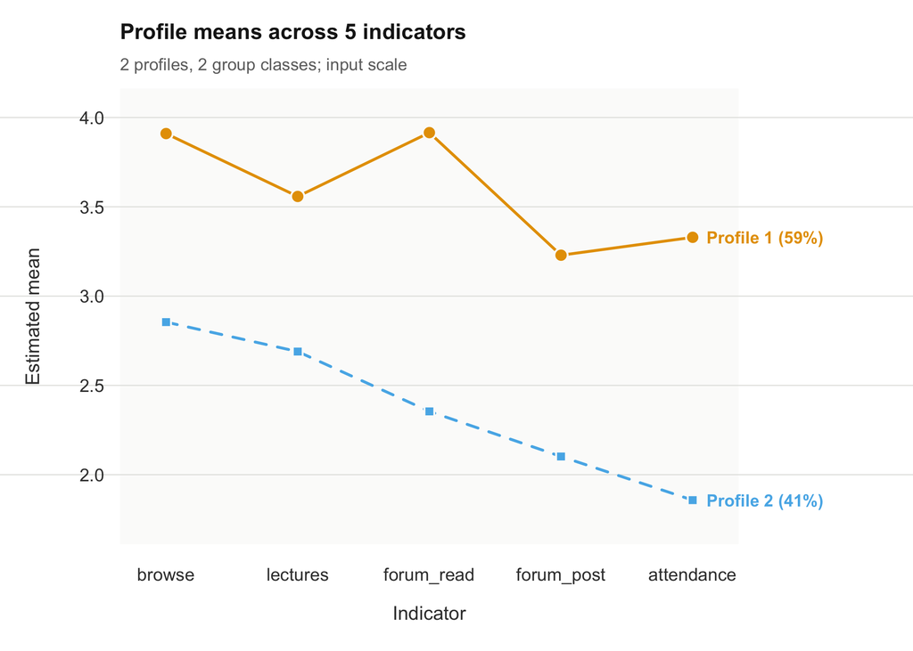

```r
plot(fit)
```

The picture is a level ordering, not a set of shapes. One profile sits high on all five indicators at once; the other sits low on all five, and the gap between them runs between roughly one and a quarter and two and a half within-profile standard deviations on every indicator. They separate in the same direction every time.

That is worth stating plainly, because it is the kind of result that is easy to over-read. These data contain no kind of enrolment in which a student browses heavily while never posting, or watches every lecture and reads no forum. Engagement here moves as a block. Two profiles is the right number for describing *how much*, not *in what way*.

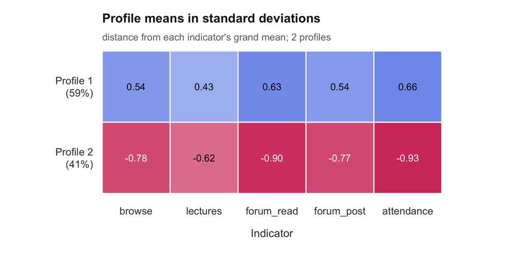

```r
plot(fit, what = "heatmap")
```

The heatmap says the same thing in standard deviations from each indicator’s grand mean, which is the view to use when the indicators are on different scales or when there are more of them than a line plot can label.

### Did it find what made the data?

This is the check simulated data exist for. `assignments()` puts each enrolment’s estimated profile in the same row as the column that generated it, so nothing has to be lined up by hand:

```r
recovery <- assignments(fit, data = course_engagement)

xtabs(~ profile + engagement, data = recovery)
```

```
#>        engagement
#> profile disengaged engaged
#>       1         11     824
#>       2        574      13
```

Read the table before reading the diagonal. **Fitted profile 1 is the generated `engaged` pattern.** Nothing in a mixture likelihood distinguishes “profile 1” from “profile 2” — permuting the labels leaves the likelihood exactly where it was — so the correspondence has to be read off the table rather than assumed from the numbering. This is label switching; it is a real property of the model and not a defect in the fit, and the correct response is to name it, not to reorder anything until the diagonal lines up. Section 6 will produce a fit where it comes out the other way round.

With that read the right way round, **24** enrolments out of **1422** are on the wrong side. That is not a claim about this package’s accuracy in general — the profiles here are far apart by construction, and real indicators overlap much more. It is a statement that the estimator does what it says, which is the only thing a simulation can establish.

Verbs that bring in a column the model never saw get their own function with its own documented arguments, rather than another `as.data.frame(what =)` value. `assignments()` owns the alignment: a frame with the wrong number of rows is refused, a frame whose indicator values disagree row by row with what the fit holds is refused, and a column its output would overwrite is an error rather than a silent replacement.

## 4. The student classes: what a whole student looks like

Everything so far could have come from a single-level model. The second level is where the enrolments belonging to one student are tied together, and a student class is defined by nothing except the mix of profiles its enrolments produce.

```r
as.data.frame(fit, what = "profile_probabilities")
```

| group_class | profile | probability | group_class_probability |
| --- | --- | --- | --- |
| 1 | 1 | 0.1697 | 0.3255 |
| 1 | 2 | 0.8303 | 0.3255 |
| 2 | 1 | 0.7881 | 0.6745 |
| 2 | 2 | 0.2119 | 0.6745 |

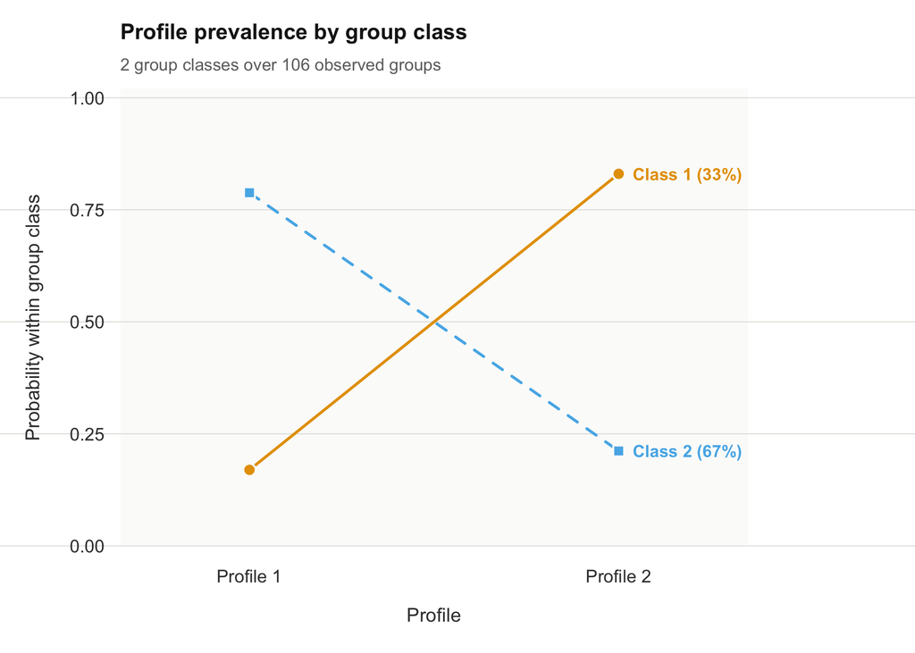

```r
plot(fit, what = "probabilities")
```

Two kinds of student, one about twice as common as the other, and the balance reverses between them: the profile that is the clear majority in one kind is the clear minority in the other. That reversal is why the lines cross, and it is the quantity a single-level model cannot report at all.

Read the size of the minority carefully, because it is the honest limit of the finding. Neither kind of student is homogeneous. Roughly one enrolment in five in each kind belongs to the *other* profile, and no student class is anywhere near pure. These are students who differ in their mix, not students who produce only one kind of enrolment — which is exactly what the model claims and exactly what the data were generated from.

### Do the classes recover the kinds of student?

Section 3 checked the measurement model against the truth. The second level has a truth column of its own, and `student_type` is constant within a student, so the check is one row per student rather than per enrolment:

```r
by_student <- unique(subset(recovery,
                            select = c(student, student_type, group_class)))

xtabs(~ group_class + student_type, data = by_student)
```

```
#>            student_type
#> group_class committed wavering
#>           1         1       34
#>           2        61       10
```

Class 2 — the class whose enrolments are mostly the engaged profile — is the committed students, and class 1 is the wavering ones. Compare the count on the wrong side of that table with section 3’s. A student class is recovered distinctly less cleanly than an enrolment’s profile, and the reason is structural rather than incidental: an enrolment is classified from five indicators measured directly on it, while a student is classified only from the *mix* their thirteen-odd enrolments happen to produce, and two mixes of roughly one in five against four in five will overlap in samples of thirteen.

Compare the fitted mixes with the generating ones printed in section 1. The ordering and the rough magnitudes come back; the fitted class 1 is more extreme than the average wavering student, which is what you should expect when the class is inferred rather than given — the students it is least sure about are the ones it puts in the other class.

### What pooling costs

To see it, fit the same measurement model with a single student class. That *is* the single-level model:

```r
flat <- multilpa(course_engagement, vars = activity, id = "student",
                 n_profiles = 2, n_group_classes = 1, time = "sequence",
                 n_starts = 20, seed = 2026)

as.data.frame(flat, what = "profile_probabilities")
```

| group_class | profile | probability | group_class_probability |
| --- | --- | --- | --- |
| 1 | 1 | 0.5879 | 1 |
| 1 | 2 | 0.4121 | 1 |

One row per profile, one number each, and no way to ask the question. The two-class model also fits better by a wide margin:

```r
information_criteria(flat)
```

| log_likelihood | n_parameters | aic | kic | bic_groups | bic_individual | sabic_groups | sabic_individual | caic_groups | caic_individual | awe_groups | awe_individual | icl_groups | icl_individual | clc_groups | clc_individual |
| --- | --- | --- | --- | --- | --- | --- | --- | --- | --- | --- | --- | --- | --- | --- | --- |
| -7799 | 21 | 15639 | 15663 | 15695 | 15750 | 15629 | 15683 | 15716 | 15771 | 15856 | 16109 | 15695 | 15893 | 15597 | 15741 |

Every criterion, under both conventions, prefers the two-class model over this one — which is a much cleaner verdict than section 2’s three-profile comparison produced, and the contrast is the point: the criteria agree when the extra structure is real and argue when it is standing in for something else.

```r
lmr_lrt(flat, fit)
```

| statistic | df | n | adjustment_factor | adjusted_statistic | p_value |
| --- | --- | --- | --- | --- | --- |
| 360.4 | 2 | 1422 | 1.069 | 337.2 | NA |

The statistic is reported without a p-value on purpose. The Vermunt–Lo–Mendell–Rubin reference distribution is not implemented here, and a chi-square approximation to it is not a substitute, so the column is `NA` rather than misleading. The statistic and its adjusted version are large against two degrees of freedom, which is a reason to take the second level seriously; it is not a test, and this document does not report it as one. The criteria above are the verdict this document rests on.

### The raw data agree, without being asked to

Section 1 found a tenth to a quarter of each indicator’s variance lying between students. If the model’s claim is right — students differ in the *mix* of enrolments, not in what an engaged enrolment looks like — then that between-student variance should disappear once you condition on the profile. Split the same calculation by assigned profile:

```r
descriptives(fit, by = "profile")
```

| profile | variable | n | n_missing | mean | sd | min | max | n_distinct | n_groups | icc |
| --- | --- | --- | --- | --- | --- | --- | --- | --- | --- | --- |
| 1 | browse | 835 | 0 | 3.915 | 0.6149 | 1.66 | 5.60 | 250 | 99 | 0.0207 |
| 1 | lectures | 835 | 0 | 3.558 | 0.7740 | 1.36 | 6.21 | 292 | 99 | 0.0097 |
| 1 | forum_read | 835 | 0 | 3.921 | 0.7060 | 2.00 | 6.09 | 274 | 99 | -0.0127 |
| 1 | forum_post | 835 | 0 | 3.231 | 0.7197 | 1.11 | 6.03 | 286 | 99 | -0.0022 |
| 1 | attendance | 835 | 0 | 3.332 | 0.5805 | 1.81 | 5.12 | 240 | 99 | 0.0109 |
| 2 | browse | 587 | 0 | 2.849 | 0.5872 | 0.90 | 4.93 | 221 | 96 | 0.0077 |
| 2 | lectures | 587 | 0 | 2.691 | 0.6137 | 0.59 | 4.43 | 221 | 96 | 0.0236 |
| 2 | forum_read | 587 | 0 | 2.349 | 0.6075 | 0.43 | 4.27 | 221 | 96 | 0.0012 |
| 2 | forum_post | 587 | 0 | 2.101 | 0.5559 | 0.42 | 3.96 | 211 | 96 | 0.0107 |
| 2 | attendance | 587 | 0 | 1.856 | 0.5628 | 0.25 | 3.37 | 214 | 96 | 0.0054 |

The intraclass correlations collapse to near zero or below. Within a profile the students no longer differ. The model was never shown this calculation; it is the data agreeing with the model on a quantity the model did not fit.

```r
head(as.data.frame(fit, what = "group_posteriors"))
```

| group | group_size | log_likelihood | group_class | posterior | modal |
| --- | --- | --- | --- | --- | --- |
| 1 | 13 | -55.26 | 1 | 1.0000 | TRUE |
| 2 | 13 | -63.18 | 1 | 1.0000 | TRUE |
| 3 | 14 | -69.76 | 1 | 0.0000 | FALSE |
| 4 | 13 | -57.31 | 1 | 0.0000 | FALSE |
| 5 | 14 | -69.24 | 1 | 1.0000 | TRUE |
| 6 | 12 | -75.17 | 1 | 0.0118 | FALSE |

One row per student per class, with the student’s own contribution to the likelihood and the posterior behind the assignment. The posterior is the honest object here: the modal class is a summary of it, not a fact about the student.

## 5. Order: what using the sequence buys

A student class is a probability mix, and a mix is an average over careers that may look nothing like each other. Section 2’s model stored the ordering and ignored it. This section reads it back, and then spends the same parameters on a model that uses it.

```r
sequence_summary(fit)
```

| group_class | groups | observations | mean_length | median_length | shortest | longest | complete | gaps |
| --- | --- | --- | --- | --- | --- | --- | --- | --- |
| 1 | 35 | 466 | 13.31 | 13 | 10 | 15 | 8 | 0 |
| 2 | 71 | 956 | 13.46 | 14 | 11 | 15 | 16 | 0 |

Every student contributes between ten and fifteen enrolments with no gaps, so nothing in what follows is about attrition — the panel is ragged, not incomplete.

```r
head(sequences(fit, format = "wide"), 8)
```

| group | group_class | sequence_1 | sequence_2 | sequence_3 | sequence_4 | sequence_5 | sequence_6 | sequence_7 | sequence_8 | sequence_9 | sequence_10 | sequence_11 | sequence_12 | sequence_13 | sequence_14 | sequence_15 |
| --- | --- | --- | --- | --- | --- | --- | --- | --- | --- | --- | --- | --- | --- | --- | --- | --- |
| 1 | 1 | 1 | 1 | 2 | 2 | 2 | 2 | 2 | 2 | 2 | 2 | 2 | 2 | 2 | NA | NA |
| 2 | 1 | 2 | 2 | 2 | 2 | 2 | 2 | 2 | 2 | 2 | 2 | 2 | 2 | 2 | NA | NA |
| 3 | 2 | 1 | 1 | 1 | 1 | 1 | 1 | 1 | 1 | 1 | 1 | 1 | 1 | 1 | 1 | NA |
| 4 | 2 | 1 | 1 | 1 | 1 | 1 | 1 | 1 | 1 | 1 | 1 | 1 | 1 | 1 | NA | NA |
| 5 | 1 | 2 | 2 | 2 | 2 | 2 | 2 | 2 | 1 | 2 | 2 | 2 | 2 | 2 | 2 | NA |
| 6 | 2 | 1 | 2 | 2 | 2 | 1 | 1 | 1 | 1 | 2 | 1 | 1 | 1 | NA | NA | NA |
| 7 | 2 | 1 | 1 | 1 | 1 | 1 | 1 | 1 | 1 | 1 | 1 | 1 | 1 | 1 | 1 | 1 |
| 8 | 1 | 1 | 2 | 2 | 2 | 2 | 2 | 2 | 2 | 2 | 2 | 2 | 1 | 1 | 1 | NA |

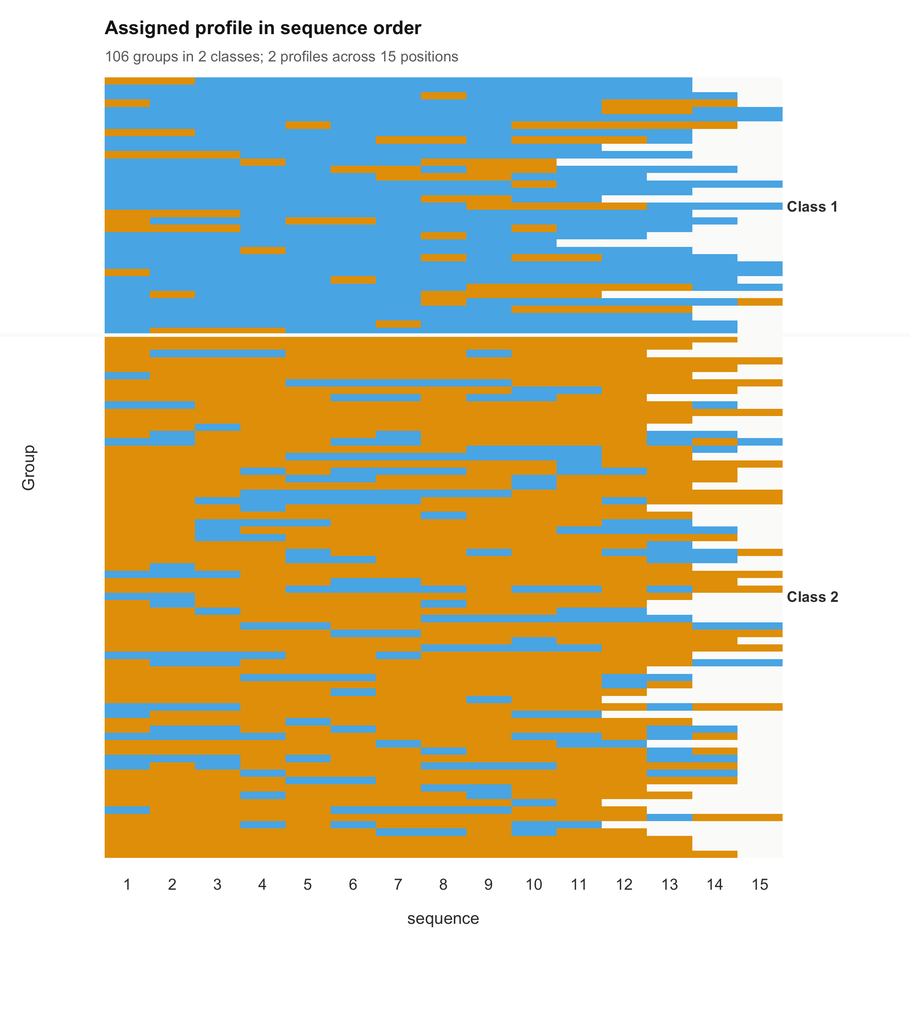

```r
plot(fit, what = "sequences")
```

Each row is one student, each column one position in that student’s own course order, with students blocked by their class. Read the wide table above rather than the picture if you want to check this: the positions within a row come in runs. A student holds a profile for a stretch and then switches, rather than alternating. The model that produced those assignments knows nothing about that — it scored position 14 the same way it scored position 1 — which is precisely the gap the next model closes.

### The model that uses order

`fit_transitions()` estimates first-order transition probabilities between profiles across the occasions, by a forward–backward EM algorithm. On these data it costs **exactly the same number of parameters** as the mixture above.

```r
moves <- fit_transitions(course_engagement, vars = activity, id = "student",
                         time = "sequence", n_profiles = 2,
                         n_starts = 20, seed = 2026)

transitions(moves)
```

| group_class | from | to | probability | expected_count | stable | estimated | group_class_probability |
| --- | --- | --- | --- | --- | --- | --- | --- |
| 1 | 1 | 1 | 0.8599 | 671.0 | TRUE | TRUE | 1 |
| 1 | 1 | 2 | 0.1401 | 109.3 | FALSE | TRUE | 1 |
| 1 | 2 | 1 | 0.1891 | 101.3 | FALSE | TRUE | 1 |
| 1 | 2 | 2 | 0.8109 | 434.4 | TRUE | TRUE | 1 |

The `stable` column marks the diagonal — staying in the same profile from one course to the next. Both diagonal entries are far above the corresponding off-diagonal ones, which is the persistence the wide table showed as runs, now estimated rather than eyeballed.

Now compare the two models on the criteria. Same data, same indicators, same number of parameters; the only difference is whether the ordering is used:

```r
information_criteria(moves)
```

| log_likelihood | n_parameters | aic | kic | bic_groups | bic_individual | sabic_groups | sabic_individual | caic_groups | caic_individual | awe_groups | awe_individual | icl_groups | icl_individual | clc_groups | clc_individual |
| --- | --- | --- | --- | --- | --- | --- | --- | --- | --- | --- | --- | --- | --- | --- | --- |
| -7522 | 23 | 15090 | 15116 | 15151 | 15211 | 15078 | 15138 | 15174 | 15234 | 15327 | 15525 | 15151 | 15289 | 15044 | 15122 |

The ordered model reaches a higher likelihood for the same twenty-three parameters, and every criterion — under either sample-size convention — falls. That is the cost of ignoring order, measured rather than asserted. It is also the honest answer to the objection people raise about latent profile analysis: the mixture is not wrong, it answers a different question, and when order genuinely exists, the model that uses it is the better description.

The improvement is not only in the likelihood. Run section 3’s recovery check against the ordered model’s assignments:

```r
recovery_moves <- assignments(moves, data = course_engagement)

xtabs(~ profile + engagement, data = recovery_moves)
```

```
#>        engagement
#> profile disengaged engaged
#>       1         12     827
#>       2        573      10
```

**22** enrolments on the wrong side, against section 3’s **24**. Knowing that a student was engaged in the previous course is evidence about this one, and the mixture had no way to use it. The improvement is small because the profiles are already far apart; where they overlap more, the ordering carries proportionally more of the classification.

### And the second level the transition model also needs

A latent transition model can carry a second level of its own, letting different kinds of student have different transition matrices. Ask for one:

```r
moves_two <- fit_transitions(course_engagement, vars = activity, id = "student",
                             time = "sequence", n_profiles = 2,
                             n_group_classes = 2, n_starts = 20, seed = 2026)

summary(moves_two)
```

```
#> Latent transition model: 2 profiles and 2 group classes
#> Observations: 1422; groups: 106; up to 15 occasions (unbalanced, observed grid)
#> Parameters: 27; converged: TRUE
#>
#> Profile means:
#>           browse lectures forum_read forum_post attendance
#> profile_1  3.912    3.561      3.915      3.229      3.326
#> profile_2  2.852    2.686      2.356      2.102      1.863
#>
#> Profile standard deviations:
#>           browse lectures forum_read forum_post attendance
#> profile_1 0.6185   0.7701     0.7136     0.7175     0.5876
#> profile_2 0.5859   0.6124     0.6127     0.5612     0.5721
#>
#> Initial profile probabilities within each group class:
#>               profile_1 profile_2
#> group_class_1    0.2706    0.7294
#> group_class_2    0.8184    0.1816
#>
#> Transition probabilities (rows: profile moved from):
#> , , group_class_1
#>
#>           profile_1 profile_2
#> profile_1   0.73693    0.2631
#> profile_2   0.06991    0.9301
#>
#> , , group_class_2
#>
#>           profile_1 profile_2
#> profile_1    0.8766    0.1234
#> profile_2    0.4367    0.5633
#>
#>
#> Group-class probabilities:
#> group_class_1 group_class_2
#>        0.3569        0.6431
#>
#> Effective individual memberships:
#> profile_1 profile_2
#>     835.4     586.6
#>
#> Log likelihood: -7500.066326; AIC: 15054.133
#> BIC (groups): 15126.046; BIC (individuals): 15196.148
#> Best likelihood replicated in 20/20 starts (absolute tolerance 0.0075).
#>
#> Estimates as tidy tables: as.data.frame(summary(fit))
```

```r
transitions(moves_two)
```

| group_class | from | to | probability | expected_count | stable | estimated | group_class_probability |
| --- | --- | --- | --- | --- | --- | --- | --- |
| 1 | 1 | 1 | 0.7369 | 80.00 | TRUE | TRUE | 0.3569 |
| 1 | 1 | 2 | 0.2631 | 28.55 | FALSE | TRUE | 0.3569 |
| 1 | 2 | 1 | 0.0699 | 25.21 | FALSE | TRUE | 0.3569 |
| 1 | 2 | 2 | 0.9301 | 335.36 | TRUE | TRUE | 0.3569 |
| 2 | 1 | 1 | 0.8766 | 586.45 | TRUE | TRUE | 0.6431 |
| 2 | 1 | 2 | 0.1234 | 82.54 | FALSE | TRUE | 0.6431 |
| 2 | 2 | 1 | 0.4367 | 77.70 | FALSE | TRUE | 0.6431 |
| 2 | 2 | 2 | 0.5633 | 100.18 | TRUE | TRUE | 0.6431 |

Two very different regimes, and nothing here is on a boundary: no persistence is 1, and the best likelihood replicates across every start. One class holds the low profile far more tightly than it holds the high one; the other does the reverse, and leaves the low profile nearly half the times it is there. That is the same committed-and-wavering distinction section 4 found in the mix, now expressed as movement, and the two model families agree about which student is which:

```r
xtabs(~ group_class + student_type,
      data = unique(subset(assignments(moves_two, data = course_engagement),
                           select = c(student, student_type, group_class))))
```

```
#>            student_type
#> group_class committed wavering
#>           1         1       34
#>           2        61       10
```

```r
information_criteria(moves_two)
```

| log_likelihood | n_parameters | aic | kic | bic_groups | bic_individual | sabic_groups | sabic_individual | caic_groups | caic_individual | awe_groups | awe_individual | icl_groups | icl_individual | clc_groups | clc_individual |
| --- | --- | --- | --- | --- | --- | --- | --- | --- | --- | --- | --- | --- | --- | --- | --- |
| -7500 | 27 | 15054 | 15084 | 15126 | 15196 | 15041 | 15110 | 15153 | 15223 | 15376 | 15552 | 15169 | 15275 | 15043 | 15079 |

The verdict is mostly but not unanimously for the second level. AIC, KIC, BIC, SABIC, CAIC and CLC all fall under both conventions — CLC on the group convention by a single point — and ICL falls under the individual convention; AWE rises under both conventions, and ICL under the group convention rises too. AWE is the heaviest penalty in the set and the group convention charges each of the four extra parameters against 106 units rather than 1422, so the dissent comes from exactly the criteria most reluctant about parameters. Declaring a convention in advance, as section 2 said, is what keeps this from becoming a choice made after seeing the answer.

## 6. Prediction: `previous_grade`, one step and three

Nothing so far has used `previous_grade`. It is not an indicator — it is not a measure of engagement in this course — so it does not belong in `vars`. It is a predictor of *which profile* an enrolment falls into, and there are two places to put it.

### Three steps: fix the model, then regress

`r3step()` takes the model exactly as fitted above and regresses class membership on the covariate afterwards, correcting for classification error. The measurement model is untouched, which is the whole appeal: the covariate cannot move the profiles.

```r
r3step(fit, data = course_engagement, covariates = "previous_grade")
```

| level | outcome | term | estimate | standard_error | statistic | p_value | p_value_adjusted | conf_low | conf_high |
| --- | --- | --- | --- | --- | --- | --- | --- | --- | --- |
| individuals | class_1 | (Intercept) | 0.3812 | 0.0579 | 6.582 | 0 | NA | 0.2677 | 0.4946 |
| individuals | class_1 | previous_grade | 0.5741 | 0.0617 | 9.298 | 0 | 0 | 0.4531 | 0.6951 |

One logit, because there are two profiles. `class_1` is the engaged profile, as section 3 established, and the coefficient is positive: a student who did better in their previous course is more likely to be engaged in this one.

### One step: the covariate inside the model

`fit_covariates()` puts the same covariate in the membership model and estimates everything together.

```r
cov_fit <- fit_covariates(course_engagement, vars = activity, id = "student",
                          n_profiles = 2, n_group_classes = 2,
                          profile_covariates = "previous_grade",
                          time = "sequence", n_starts = 20, seed = 2026)

as.data.frame(cov_fit, what = "coefficients")
```

| level | outcome | term | parameter | estimate |
| --- | --- | --- | --- | --- |
| profile | profile_1 | group_class_1 | logit | -1.2798 |
| profile | profile_1 | group_class_2 | logit | 1.5409 |
| profile | profile_1 | previous_grade | logit | -0.4404 |
| group | group_class_1 | (Intercept) | logit | 0.7585 |

Here is the label switching section 3 promised: in this fit `profile_1` is the *disengaged* pattern, so its negative `previous_grade` coefficient is the same finding in the mirror. Check that against the profile means rather than taking the sign on trust:

```r
as.data.frame(cov_fit)
```

| profile | indicator | mean | variance | standard_deviation |
| --- | --- | --- | --- | --- |
| 1 | browse | 2.855 | 0.3519 | 0.5932 |
| 1 | lectures | 2.688 | 0.3729 | 0.6106 |
| 1 | forum_read | 2.356 | 0.3763 | 0.6134 |
| 1 | forum_post | 2.102 | 0.3133 | 0.5598 |
| 1 | attendance | 1.859 | 0.3221 | 0.5676 |
| 2 | browse | 3.911 | 0.3807 | 0.6170 |
| 2 | lectures | 3.560 | 0.5962 | 0.7722 |
| 2 | forum_read | 3.916 | 0.5078 | 0.7126 |
| 2 | forum_post | 3.229 | 0.5161 | 0.7184 |
| 2 | attendance | 3.329 | 0.3397 | 0.5829 |

Those are section 3’s two profiles, every mean within a hundredth, with their numbers exchanged. That is the reassuring outcome and it is not guaranteed: the appeal of the three-step approach is precisely that a covariate *cannot* reshape the measurement model, and the price of one-step estimation is that it can. Here it did not, so the two approaches are estimating the same thing and can be compared.

The accessor prints the coefficients without standard errors; `parameter_inference()` supplies them:

```r
subset(parameter_inference(cov_fit), level != "measurement")
```

|  | level | outcome | term | parameter | estimate | standard_error | statistic | p_value | p_adjusted | conf_low | conf_high |
| --- | --- | --- | --- | --- | --- | --- | --- | --- | --- | --- | --- |
| 21 | profile | profile_1 | group_class_1 | coefficient | -1.2798 | 0.0945 | -13.537 | 0e+00 | 0e+00 | -1.4651 | -1.095 |
| 22 | profile | profile_1 | group_class_2 | coefficient | 1.5409 | 0.1687 | 9.132 | 0e+00 | 0e+00 | 1.2101 | 1.872 |
| 23 | profile | profile_1 | previous_grade | coefficient | -0.4404 | 0.0737 | -5.978 | 0e+00 | 0e+00 | -0.5848 | -0.296 |
| 24 | group | group_class_1 | (Intercept) | coefficient | 0.7585 | 0.2224 | 3.410 | 6e-04 | 6e-04 | 0.3225 | 1.194 |

```r
information_criteria(cov_fit)
```

| log_likelihood | n_parameters | aic | kic | bic_groups | bic_individual | sabic_groups | sabic_individual | caic_groups | caic_individual | awe_groups | awe_individual | icl_groups | icl_individual | clc_groups | clc_individual |
| --- | --- | --- | --- | --- | --- | --- | --- | --- | --- | --- | --- | --- | --- | --- | --- |
| -7600 | 24 | 15248 | 15275 | 15312 | 15374 | 15236 | 15298 | 15336 | 15398 | 15506 | 15725 | 15322 | 15479 | 15211 | 15305 |

Against section 2’s table, one extra parameter buys an improvement on every criterion under both conventions. `previous_grade` belongs in the model.

### Why the two coefficients disagree

The three-step slope and the one-step slope are not the same number, and the gap is larger than either standard error. That is not a defect in either verb; they are answering slightly different questions, and it is worth finding out which difference is responsible before reporting either.

The candidate explanation is the second level. The one-step model carries a separate intercept for each student class, so its slope is a *within-class* slope: the effect of a good previous grade on a student of a given kind. `r3step()` regresses membership on the covariate with a single intercept, so its slope also carries whatever the covariate says about which kind of student this is. And it says a good deal:

```r
aggregate(previous_grade ~ student_type, data = course_engagement, FUN = mean)
```

| student_type | previous_grade |
| --- | --- |
| committed | 0.1873 |
| wavering | -0.2706 |

Committed students earn better grades *and* produce more engaged enrolments, so a pooled slope picks up both associations at once.

That is a hypothesis about the difference, so test it: fit the one-step model with the second level removed, which leaves a single intercept, and see whether its slope moves to meet the three-step one.

```r
cov_flat <- fit_covariates(course_engagement, vars = activity, id = "student",
                           n_profiles = 2, n_group_classes = 1,
                           profile_covariates = "previous_grade",
                           time = "sequence", n_starts = 20, seed = 2026)

as.data.frame(cov_flat, what = "coefficients")
```

| level | outcome | term | parameter | estimate |
| --- | --- | --- | --- | --- |
| profile | profile_1 | group_class_1 | logit | 0.3837 |
| profile | profile_1 | previous_grade | logit | 0.5650 |

```r
head(as.data.frame(cov_flat), 5)
```

| profile | indicator | mean | variance | standard_deviation |
| --- | --- | --- | --- | --- |
| 1 | browse | 3.908 | 0.3834 | 0.6192 |
| 1 | lectures | 3.561 | 0.5949 | 0.7713 |
| 1 | forum_read | 3.911 | 0.5122 | 0.7156 |
| 1 | forum_post | 3.229 | 0.5158 | 0.7182 |
| 1 | attendance | 3.329 | 0.3387 | 0.5820 |

The labels have landed the other way round again — the five means printed underneath identify this fit’s `profile_1` as the engaged one — so this coefficient is directly comparable with `r3step()`’s, and both the slope and the intercept land within a standard error of it. The estimation approach was never the source of the disagreement. The second level was. Conditioning on the kind of student absorbs the between-student part of the association and leaves the within-student part, and those are different quantities with different meanings.

Which one to report depends on the question, and the question has to be stated. “Does a better previous grade predict engagement?” is the pooled slope. “Does a better previous grade predict engagement *for a given kind of student*?” is the conditional one. Reporting one and describing it as the other is the error this comparison exists to prevent.

## 7. Testing the assumption the model makes

Everything above rests on an assumption that has not yet been examined. A profile model says that, once you know which profile an enrolment belongs to, its indicators are independent of one another: whatever made a student browse a great deal is the profile, not some separate thing that also made them post. The default `covariance_model = "diagonal"` writes that down as a constraint, fixing every within-profile covariance at zero.

Nothing in the fit reports whether that constraint is reasonable. A model can be badly wrong in exactly this way and still converge from every start, replicate cleanly, and return a respectable entropy — sections 2 to 6 are the demonstration. `bivariate_residuals()` is the check.

```r
bivariate_residuals(fit)
```

| profile | indicator_1 | indicator_2 | kind | observed | expected | residual | effective_n | statistic | df | p_value |
| --- | --- | --- | --- | --- | --- | --- | --- | --- | --- | --- |
| profile_1 | lectures | attendance | gaussian | 0.2552 | 0 | 0.2552 | 835.7 | 7.5303 | NA | 0.0000 |
| profile_2 | forum_read | attendance | gaussian | 0.2158 | 0 | 0.2158 | 586.3 | 5.2961 | NA | 0.0000 |
| profile_1 | forum_read | attendance | gaussian | 0.2044 | 0 | 0.2044 | 835.7 | 5.9839 | NA | 0.0000 |
| profile_1 | forum_post | attendance | gaussian | 0.2008 | 0 | 0.2008 | 835.7 | 5.8746 | NA | 0.0000 |
| profile_2 | browse | attendance | gaussian | 0.1979 | 0 | 0.1979 | 586.3 | 4.8430 | NA | 0.0000 |
| profile_1 | browse | attendance | gaussian | 0.1634 | 0 | 0.1634 | 835.7 | 4.7591 | NA | 0.0000 |
| profile_2 | lectures | attendance | gaussian | 0.1192 | 0 | 0.1192 | 586.3 | 2.8922 | NA | 0.0038 |
| profile_2 | forum_post | attendance | gaussian | 0.1099 | 0 | 0.1099 | 586.3 | 2.6660 | NA | 0.0077 |
| profile_2 | browse | forum_read | gaussian | 0.0924 | 0 | 0.0924 | 586.3 | 2.2387 | NA | 0.0252 |
| profile_1 | browse | forum_post | gaussian | -0.0473 | 0 | -0.0473 | 835.7 | -1.3653 | NA | 0.1722 |
| profile_2 | forum_read | forum_post | gaussian | 0.0469 | 0 | 0.0469 | 586.3 | 1.1331 | NA | 0.2572 |
| profile_1 | browse | forum_read | gaussian | 0.0350 | 0 | 0.0350 | 835.7 | 1.0105 | NA | 0.3123 |
| profile_2 | browse | lectures | gaussian | -0.0332 | 0 | -0.0332 | 586.3 | -0.8030 | NA | 0.4220 |
| profile_1 | lectures | forum_post | gaussian | 0.0198 | 0 | 0.0198 | 835.7 | 0.5702 | NA | 0.5686 |
| profile_1 | forum_read | forum_post | gaussian | -0.0097 | 0 | -0.0097 | 835.7 | -0.2806 | NA | 0.7790 |
| profile_2 | browse | forum_post | gaussian | 0.0086 | 0 | 0.0086 | 586.3 | 0.2070 | NA | 0.8360 |
| profile_2 | lectures | forum_post | gaussian | 0.0081 | 0 | 0.0081 | 586.3 | 0.1954 | NA | 0.8450 |
| profile_2 | lectures | forum_read | gaussian | -0.0046 | 0 | -0.0046 | 586.3 | -0.1102 | NA | 0.9123 |
| profile_1 | lectures | forum_read | gaussian | 0.0046 | 0 | 0.0046 | 835.7 | 0.1314 | NA | 0.8955 |
| profile_1 | browse | lectures | gaussian | -0.0029 | 0 | -0.0029 | 835.7 | -0.0842 | NA | 0.9329 |

One row per pair of indicators per profile, worst first. `observed` is the association still present inside the profile, `expected` is what the fitted covariance model implies for it, and `residual` is the gap. Both are on the correlation scale, so the rows are comparable.

This convicts. The largest gap is 0.255, **9** of the **20** pairs fall below the conventional level, and the smallest p-values are not marginal — they are the kind that survive any correction you care to apply to twenty tests. This is not one unlucky pair in a family of comparisons. It is a structural feature of the data.

And it names its own cause. **8** of the significant pairs involve `attendance`, in both profiles, always positive. Pooling the profiles says the same thing more starkly:

```r
bivariate_residuals(fit, by = "overall")
```

| profile | indicator_1 | indicator_2 | kind | observed | expected | residual | effective_n | statistic | df | p_value |
| --- | --- | --- | --- | --- | --- | --- | --- | --- | --- | --- |
| overall | forum_read | attendance | gaussian | 0.2083 | 0 | 0.2083 | 1422 | 7.9631 | NA | 0.0000 |
| overall | lectures | attendance | gaussian | 0.2066 | 0 | 0.2066 | 1422 | 7.8959 | NA | 0.0000 |
| overall | browse | attendance | gaussian | 0.1771 | 0 | 0.1771 | 1422 | 6.7414 | NA | 0.0000 |
| overall | forum_post | attendance | gaussian | 0.1684 | 0 | 0.1684 | 1422 | 6.4042 | NA | 0.0000 |
| overall | browse | forum_read | gaussian | 0.0560 | 0 | 0.0560 | 1422 | 2.1124 | NA | 0.0347 |
| overall | browse | forum_post | gaussian | -0.0279 | 0 | -0.0279 | 1422 | -1.0521 | NA | 0.2927 |
| overall | lectures | forum_post | gaussian | 0.0162 | 0 | 0.0162 | 1422 | 0.6120 | NA | 0.5405 |
| overall | browse | lectures | gaussian | -0.0134 | 0 | -0.0134 | 1422 | -0.5046 | NA | 0.6139 |
| overall | forum_read | forum_post | gaussian | 0.0083 | 0 | 0.0083 | 1422 | 0.3144 | NA | 0.7532 |
| overall | lectures | forum_read | gaussian | 0.0016 | 0 | 0.0016 | 1422 | 0.0606 | NA | 0.9517 |

Every pair involving `attendance` is significant; no pair among the four click measures is, except `browse` with `forum_read` at the edge.

`?course_engagement` and `data-raw/course-engagement.R` say why, and it is deliberate. `attendance` is the number of days the student was active, and a student is recorded present on a day *because* they clicked something. It is not an independent fifth measurement of engagement — it is a coarsened function of the other four, which is what the real export it is calibrated against also shows. The indicators are locally dependent by construction, so the diagonal covariance model is knowably wrong, and the diagnostic found it without being told where to look.

### What the unconstrained model buys

```r
full <- multilpa(course_engagement, vars = activity, id = "student",
                 n_profiles = 2, n_group_classes = 2, time = "sequence",
                 n_starts = 20, covariance_model = "full", seed = 2026)

information_criteria(full)
```

| log_likelihood | n_parameters | aic | kic | bic_groups | bic_individual | sabic_groups | sabic_individual | caic_groups | caic_individual | awe_groups | awe_individual | icl_groups | icl_individual | clc_groups | clc_individual |
| --- | --- | --- | --- | --- | --- | --- | --- | --- | --- | --- | --- | --- | --- | --- | --- |
| -7495 | 43 | 15075 | 15121 | 15190 | 15302 | 15054 | 15165 | 15233 | 15345 | 15529 | 15907 | 15199 | 15466 | 14999 | 15154 |

Twenty extra parameters, and the log-likelihood improves by more than a hundred points. Set that beside section 2’s table: every criterion prefers the unconstrained model except AWE under the individual convention, and AWE under the group convention is a tie to within a point. AWE is the heaviest penalty in the set and it also charges for classification entropy, which — as the next table shows — the unconstrained model spends.

```r
head(bivariate_residuals(full), 4)
```

| profile | indicator_1 | indicator_2 | kind | observed | expected | residual | effective_n | statistic | df | p_value |
| --- | --- | --- | --- | --- | --- | --- | --- | --- | --- | --- |
| profile_2 | browse | forum_read | gaussian | 0.0982 | 0.0982 | 0 | 582.9 | -8e-04 | NA | 0.9994 |
| profile_2 | forum_read | attendance | gaussian | 0.2400 | 0.2400 | 0 | 582.9 | -8e-04 | NA | 0.9994 |
| profile_1 | forum_read | forum_post | gaussian | -0.0015 | -0.0016 | 0 | 839.1 | 8e-04 | NA | 0.9993 |
| profile_2 | browse | attendance | gaussian | 0.2153 | 0.2154 | 0 | 582.9 | -7e-04 | NA | 0.9995 |

The residuals are gone: `expected` now tracks `observed` to four decimal places, and **0** of the 20 pairs is significant. The fix works, and it works on the quantity the diagnostic was measuring rather than on some proxy for it.

`covariance_model = "full"` is the right choice when the residuals say so and the wrong choice when they do not — twenty parameters spent on associations that are not there would have cost exactly as much and bought nothing.

### What survived, and what did not

Before rewriting six sections, check what actually changed.

```r
as.data.frame(full)
```

| profile | indicator | mean | variance | standard_deviation |
| --- | --- | --- | --- | --- |
| 1 | browse | 3.906 | 0.3839 | 0.6196 |
| 1 | lectures | 3.555 | 0.5986 | 0.7737 |
| 1 | forum_read | 3.909 | 0.5165 | 0.7187 |
| 1 | forum_post | 3.225 | 0.5209 | 0.7218 |
| 1 | attendance | 3.317 | 0.3549 | 0.5957 |
| 2 | browse | 2.854 | 0.3519 | 0.5933 |
| 2 | lectures | 2.688 | 0.3740 | 0.6115 |
| 2 | forum_read | 2.355 | 0.3766 | 0.6137 |
| 2 | forum_post | 2.101 | 0.3109 | 0.5576 |
| 2 | attendance | 1.866 | 0.3355 | 0.5792 |

```r
as.data.frame(full, what = "profile_probabilities")
```

| group_class | profile | probability | group_class_probability |
| --- | --- | --- | --- |
| 1 | 1 | 0.1633 | 0.3229 |
| 1 | 2 | 0.8367 | 0.3229 |
| 2 | 1 | 0.7923 | 0.6771 |
| 2 | 2 | 0.2077 | 0.6771 |

The profiles are section 3’s profiles, every mean within about a hundredth, and the class mixes are section 4’s mixes to within a percentage point. The substantive description — two levels of engagement, two kinds of student differing in their mix, roughly one enrolment in five belonging to the other profile in each kind — is unchanged.

```r
xtabs(~ profile + engagement,
      data = assignments(full, data = course_engagement))
```

```
#>        engagement
#> profile disengaged engaged
#>       1         15     825
#>       2        570      12
```

```r
entropy_table(full)
```

| level | n_classes | n_units | entropy_sum | relative_entropy |
| --- | --- | --- | --- | --- |
| individuals | 2 | 1422 | 82.221 | 0.9166 |
| groups | 2 | 106 | 4.677 | 0.9363 |

Recovery is fractionally *worse* than the diagonal model’s, and the relative entropy for enrolments is lower than the number section 8 will report for the diagonal fit. Both are worth pausing on: a model that fits enormously better is not automatically a better classifier or a more confident one. Modelling the shared variance between `attendance` and the clicks correctly removes some of the apparent separation between the profiles, because part of that separation was the same information counted five times. The diagonal model was over-confident, and over-confidence flatters both a confusion matrix and an entropy.

### Back to the class count

Now section 2 can be settled. Its three-profile solution replicated from every start and won almost every criterion. If that third profile was fitting the local dependence rather than a third kind of enrolment, then it should stop paying for itself once the covariances are estimated. Fit it and see:

```r
three_full <- multilpa(course_engagement, vars = activity, id = "student",
                       n_profiles = 3, n_group_classes = 2, time = "sequence",
                       n_starts = 20, covariance_model = "full", seed = 2026)

summary(three_full)
```

```
#> Multilevel LPA: 3 profiles and 2 group classes
#> Individuals: 1422; groups: 106; parameters: 65; converged: TRUE
#>
#> Profile means:
#>           browse lectures forum_read forum_post attendance
#> profile_1  3.867    3.561      3.887      3.281      3.343
#> profile_2  2.851    2.687      2.353      2.107      1.869
#> profile_3  4.129    3.530      4.027      2.888      3.154
#>
#> Profile standard deviations:
#>           browse lectures forum_read forum_post attendance
#> profile_1 0.6170   0.8263     0.7180     0.7154     0.5853
#> profile_2 0.5916   0.6131     0.6129     0.5581     0.5813
#> profile_3 0.5784   0.3452     0.7029     0.7043     0.6591
#>
#> Profile residual covariance matrices:
#> , , profile_1
#>
#>               browse  lectures forum_read forum_post attendance
#> browse      0.380722 -0.002638    0.00541  -0.035830    0.05986
#> lectures   -0.002638  0.682798    0.01107  -0.004841    0.12422
#> forum_read  0.005410  0.011073    0.51549  -0.023900    0.08221
#> forum_post -0.035830 -0.004841   -0.02390   0.511770    0.05202
#> attendance  0.059856  0.124220    0.08221   0.052022    0.34252
#>
#> , , profile_2
#>
#>               browse  lectures forum_read forum_post attendance
#> browse      0.350020 -0.013376   0.033090   0.007735    0.07682
#> lectures   -0.013376  0.375841  -0.002413   0.004753    0.04603
#> forum_read  0.033090 -0.002413   0.375595   0.022458    0.08636
#> forum_post  0.007735  0.004753   0.022458   0.311450    0.03834
#> attendance  0.076824  0.046030   0.086357   0.038341    0.33792
#>
#> , , profile_3
#>
#>             browse lectures forum_read forum_post attendance
#> browse     0.33450  0.01995    0.06231     0.1674     0.1305
#> lectures   0.01995  0.11919   -0.02128     0.1120     0.1031
#> forum_read 0.06231 -0.02128    0.49406     0.1953     0.2133
```

[output cut: 32 more lines]

```
#>      6          -7472      TRUE        257  <NA>    FALSE
#>      7          -7478      TRUE        285  <NA>    FALSE
#>      8          -7478      TRUE        119  <NA>    FALSE
#>      9          -7478      TRUE        303  <NA>    FALSE
#>     10          -7478      TRUE        244  <NA>    FALSE
#>     11          -7478      TRUE        255  <NA>    FALSE
#>     12          -7478      TRUE        382  <NA>    FALSE
#>     13          -7478      TRUE        130  <NA>    FALSE
#>     14          -7478      TRUE        253  <NA>    FALSE
#>     15          -7478      TRUE        303  <NA>    FALSE
#>     16          -7472      TRUE        251  <NA>    FALSE
#>     17          -7478      TRUE        128  <NA>    FALSE
#>     18          -7476      TRUE        329  <NA>    FALSE
#>     19          -7478      TRUE        304  <NA>    FALSE
#>     20          -7478      TRUE        468  <NA>    FALSE
```

```r
information_criteria(three_full)
```

| log_likelihood | n_parameters | aic | kic | bic_groups | bic_individual | sabic_groups | sabic_individual | caic_groups | caic_individual | awe_groups | awe_individual | icl_groups | icl_individual | clc_groups | clc_individual |
| --- | --- | --- | --- | --- | --- | --- | --- | --- | --- | --- | --- | --- | --- | --- | --- |
| -7472 | 65 | 15073 | 15141 | 15246 | 15415 | 15041 | 15208 | 15311 | 15480 | 15751 | 16674 | 15253 | 16007 | 14950 | 15536 |

Everything that was clean about section 2’s three-profile fit is now broken. The best likelihood is found by a small minority of the twenty starts, and the rest settle elsewhere. One of the six structural probabilities is pinned at zero to ten decimal places. And set against the two-profile unconstrained model above, the criteria come back: BIC, KIC, CAIC, AWE and ICL prefer two profiles under both conventions, SABIC and CLC split by convention, and only AIC still prefers three — by about two points, which is AIC doing what AIC does in mixtures.

Compare the two-profile unconstrained model with the *three*-profile diagonal model of section 2 directly, and the same thing shows from the other side: two profiles with the covariances estimated beats three profiles with them fixed on thirteen of the fourteen columns — every one but AWE under the group convention — even though it costs eight parameters more to do it. Given the choice between spending parameters on a class and spending them on the covariances, these data want the covariances.

So the answer to section 2 is that the third profile was the misspecification. An unmodelled within-profile association has to go somewhere, and a mixture will absorb it by splitting a class — which is why an extra class can replicate from every start and still not be a kind of anything. The restart diagnostic is a necessary guard and not a sufficient one. **Run the residual check before believing a class count**, because a class count is one of the things local dependence corrupts, and it corrupts it in the direction of finding more.

## 8. How much to trust the assignments

A profile solution can be well estimated and still be too blurred to act on. Every classification diagnostic comes back from one call:

```r
diagnostics(fit)
```

```
#> Classification quality: 2 profiles, 2 group classes
#>
#>   Relative entropy     individuals 0.946    groups 0.938
#>   Smallest class       individuals 586.3 (41.2%)    groups 34.5 (32.6%)
#>   Lowest avg posterior individuals 0.983    groups 0.967
#>   Largest residual     0.255  (lectures, attendance; profile_1)
#>
#> Tables: as.data.frame(x, what = "entropy" | "classification" |
#>         "posteriors" | "residuals").  plot(x) draws them.
```

That is a summary of four tables — and note that the largest residual is on the face of it, which is how section 7’s problem would have announced itself to a reader who ran only this one verb.

### Entropy and classification quality

```r
entropy_table(fit)
```

| level | n_classes | n_units | entropy_sum | relative_entropy |
| --- | --- | --- | --- | --- |
| individuals | 2 | 1422 | 53.620 | 0.9456 |
| groups | 2 | 106 | 4.554 | 0.9380 |

Two warnings attach to that number, and both have already been earned. Section 4 is the reminder that a high group entropy is not the same as a correct group assignment: the students separate sharply *given the model*, and eleven of them are still on the wrong side of the truth table. Section 7 is the reminder that entropy is not a measure of fit at all — the diagonal model has the higher entropy of the two and is the worse model. A confident classifier and a correct one are different things.

```r
classification_table(fit, level = "both")
```

| level | class | n_modal | proportion_modal | estimated_n | estimated_proportion | average_posterior | odds_correct_classification |
| --- | --- | --- | --- | --- | --- | --- | --- |
| individuals | 1 | 835 | 0.5872 | 835.7 | 0.5877 | 0.9887 | 61.19 |
| individuals | 2 | 587 | 0.4128 | 586.3 | 0.4123 | 0.9826 | 80.65 |
| groups | 1 | 35 | 0.3302 | 34.5 | 0.3255 | 0.9675 | 61.60 |
| groups | 2 | 71 | 0.6698 | 71.5 | 0.6745 | 0.9909 | 52.82 |

The average posterior is near one at both levels, and the odds of correct classification are in the tens — against the value of 1 that a useless classifier would give.

Note also that `n_modal` and `estimated_n` agree closely at both levels. Where a model separates poorly these two diverge, because the modal count claims a certainty the posteriors do not support.

```r
classification_errors(fit)
```

| level | true_class | assigned_class | probability |
| --- | --- | --- | --- |
| individuals | 1 | 1 | 0.9878 |
| individuals | 1 | 2 | 0.0122 |
| individuals | 2 | 1 | 0.0161 |
| individuals | 2 | 2 | 0.9839 |

The same thing as a confusion matrix implied by the posteriors: how often an enrolment truly in one profile would be assigned to the other, under the model’s own account of its uncertainty. This is the model grading itself, and section 3’s table is the independent check on whether it graded honestly.

The two distributions behind the entropy number, which one number cannot show:

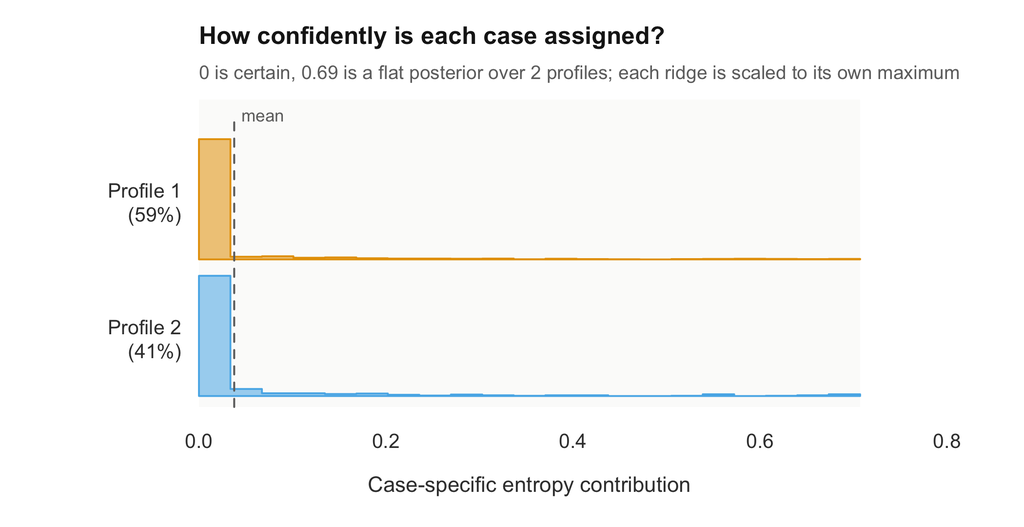

```r
plot(fit, what = "entropy")
```

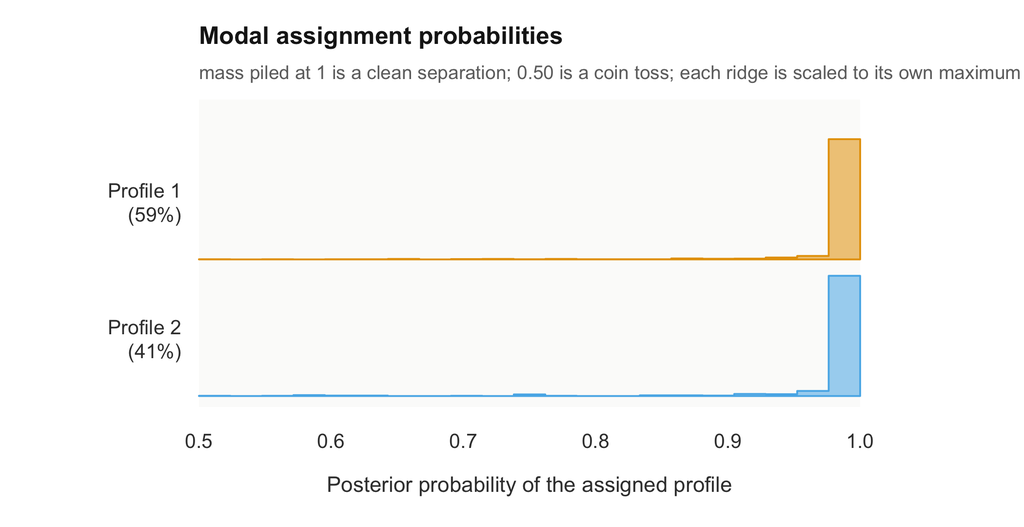

```r
plot(fit, what = "posteriors")
```

Each ridge is scaled to its own maximum, which is the usual ridgeline convention: it compares *shapes* rather than profile sizes, so prevalence is printed in each label instead. A ridge with a long tail towards the middle is where a single summary number would have misled you.

### Standard errors, and what the package refuses to certify

```r
head(parameter_inference(fit), 6)
```

| level | outcome | term | parameter | estimate | standard_error | statistic | p_value | p_adjusted | conf_low | conf_high |
| --- | --- | --- | --- | --- | --- | --- | --- | --- | --- | --- |
| measurement | profile_1 | browse | mean | 3.910 | 0.0217 | 180.3 | 0 | 0 | 3.868 | 3.953 |
| measurement | profile_1 | lectures | mean | 3.558 | 0.0272 | 131.0 | 0 | 0 | 3.505 | 3.611 |
| measurement | profile_1 | forum_read | mean | 3.915 | 0.0253 | 155.0 | 0 | 0 | 3.866 | 3.965 |
| measurement | profile_1 | forum_post | mean | 3.229 | 0.0255 | 126.8 | 0 | 0 | 3.179 | 3.279 |
| measurement | profile_1 | attendance | mean | 3.329 | 0.0207 | 160.6 | 0 | 0 | 3.289 | 3.370 |
| measurement | profile_2 | browse | mean | 2.854 | 0.0253 | 112.9 | 0 | 0 | 2.805 | 2.904 |

No qualification attached, and that is a statement rather than a silence. Wald standard errors are built from the curvature of the likelihood at a point where the score is assumed to be zero, and `parameter_inference()` checks that assumption instead of taking it on trust. Watch what the check looks like when it fails. The same model, stopped a great deal earlier:

```r
loose <- multilpa(course_engagement, vars = activity, id = "student",
                  n_profiles = 2, n_group_classes = 2, time = "sequence",
                  n_starts = 20, tol = 1e-4, seed = 2026)

head(parameter_inference(loose), 6)
```

```
#> Warning: The fitted likelihood still carries a score worth 4.3% of a standard error; refit with
#> a tighter `tol` before using Wald inference.
```

| level | outcome | term | parameter | estimate | standard_error | statistic | p_value | p_adjusted | conf_low | conf_high |
| --- | --- | --- | --- | --- | --- | --- | --- | --- | --- | --- |
| measurement | profile_1 | browse | mean | 3.911 | 0.0217 | 180.3 | 0 | 0 | 3.868 | 3.953 |
| measurement | profile_1 | lectures | mean | 3.559 | 0.0272 | 131.0 | 0 | 0 | 3.506 | 3.612 |
| measurement | profile_1 | forum_read | mean | 3.916 | 0.0252 | 155.1 | 0 | 0 | 3.867 | 3.966 |
| measurement | profile_1 | forum_post | mean | 3.230 | 0.0254 | 126.9 | 0 | 0 | 3.180 | 3.280 |
| measurement | profile_1 | attendance | mean | 3.330 | 0.0207 | 160.8 | 0 | 0 | 3.290 | 3.371 |
| measurement | profile_2 | browse | mean | 2.856 | 0.0253 | 112.9 | 0 | 0 | 2.806 | 2.905 |

That warning is `multilpa_unconverged`, and it is worth believing rather than muffling. A loose tolerance is set for the *likelihood*, and the likelihood is flat near its maximum: stopping when it stops improving can leave the parameters at a point where the score is still appreciably far from zero. That residual score is exactly the thing that invalidates the curvature calculation.

Note what this warning does *not* cover. It certifies that the optimiser arrived; it says nothing about whether the model it arrived at is the right one. Section 7’s diagonal fit passes this check and is still misspecified. Different questions, different verbs.

Robust errors accumulate the score over independent students rather than enrolments, which is the right unit when the measurement model may be misspecified — which, after section 7, is not a hypothetical here:

```r
head(parameter_inference(fit, vcov_type = "robust"), 6)
```

| level | outcome | term | parameter | estimate | standard_error | statistic | p_value | p_adjusted | conf_low | conf_high |
| --- | --- | --- | --- | --- | --- | --- | --- | --- | --- | --- |
| measurement | profile_1 | browse | mean | 3.910 | 0.0242 | 161.5 | 0 | 0 | 3.863 | 3.958 |
| measurement | profile_1 | lectures | mean | 3.558 | 0.0265 | 134.2 | 0 | 0 | 3.506 | 3.610 |
| measurement | profile_1 | forum_read | mean | 3.915 | 0.0249 | 157.4 | 0 | 0 | 3.867 | 3.964 |
| measurement | profile_1 | forum_post | mean | 3.229 | 0.0243 | 132.9 | 0 | 0 | 3.181 | 3.277 |
| measurement | profile_1 | attendance | mean | 3.329 | 0.0211 | 158.1 | 0 | 0 | 3.288 | 3.370 |
| measurement | profile_2 | browse | mean | 2.854 | 0.0244 | 117.1 | 0 | 0 | 2.807 | 2.902 |

## 9. What this model cannot tell you

**Convergence is not correctness, and neither is a criterion.** This is the document’s main finding and it was not the one it set out to make. Section 2’s three-profile model replicated from twenty starts out of twenty, sat on no boundary, and beat two profiles on almost every information criterion — and it was an artefact of an assumption nobody had checked. The restart column, the boundary flag and the criteria are all necessary and none of them is sufficient. Run `bivariate_residuals()` before you believe a class count.

**The labels are arbitrary.** Section 6 produced one fit whose `profile_1` is the opposite of section 3’s and then a second that switched back, and in both cases the correspondence had to be read off a table of means rather than inferred from the numbering. Nothing in the likelihood distinguishes “profile 1” from “profile 2”, so any comparison between two fits has to align the labels first, and no substantive claim should ever be attached to a profile number.

**A mixture is not a trajectory.** Sections 2 to 4 describe an overall mix, and “students who start strong and fade” land in the same class as “students who are consistently middling”. Section 5 measured what that costs on exactly these data: the same twenty-three parameters spent on transition probabilities instead of a mixture of enrolments bought a better fit on every criterion and a smaller recovery error. When the ordering exists, use it; when it does not, say so rather than reading a mix as a path. Note that the transition models in section 5 inherit section 7’s local dependence — they assume it away in the same place the mixture does — so that comparison is fair between the two but neither is the final model.

**Thirteen enrolments is decent evidence about a student, and not conclusive evidence.** Section 8’s entropy says the student classes separate sharply given the model; section 4’s truth table says eleven students in 106 are still in the wrong class. High entropy is a statement about the posteriors, not about correctness, and reporting a student’s modal class without its posterior overstates what is known.

**These data are simulated.** That is what allowed sections 3, 4, 5 and 7 to check the recovery at both levels against the columns that generated it, and to know in advance what the residual diagnostic ought to find. It is also the reason none of the numbers here is a finding about students. They are findings about the estimator.

### When to use which

Use `n_group_classes = 1` when the grouping exists only as a nuisance — the model then reduces to an ordinary latent profile analysis that still respects the clustering. Raise it above one when the question is about the units rather than the observations, as in sections 2 to 4. Use `fit_transitions()` when the occasions are ordered and the question is about movement, as in section 5. Use `r3step()` when a covariate must not be allowed to reshape the measurement model, and `fit_covariates()` when you want the covariate estimated jointly and have checked, as section 6 did, that the profiles survived it. Use `covariance_model = "full"` when `bivariate_residuals()` says the indicators are not conditionally independent, and only then. Use `fit_random_intercept()` when group differences are better described as a continuum than as types, and compare the two on the information criteria rather than assuming.

And run `descriptives()` before all of them, and `bivariate_residuals()` before believing any of them.

## References

Vermunt, J. K. (2003). Multilevel latent class models. *Sociological Methodology*, 33, 213–239.